# Recitation 3: Processing and Cleaning Data

Eugene Tan (TA)

9/25/2020

# Today

1. Homework Logistics
2. R Markdown Files
3. Data Analysis of EIA consumption data
4. Energy primer for this week’s reading

## R Markdown Notebook

This is the format we expect you to submit your homeworks in, allowing you to interlace code and written answers.

### Markdown

Used on github and in Rmarkdown.

```
Plain text.
End a line with two spaces to start a new paragraph.
*italics* and _italics_
**bold** and __bold__
superscript^2^
~~strikethrough~~
[link](www.rstudio.com)
```

Plain text. End a line with two spaces to start a new paragraph.  
*italics* and *italics* **bold** and **bold** superscript<sup>2</sup> strikethrough [cheatsheet 1](https://github.com/adam-p/markdown-here/wiki/Markdown-Cheatsheet) cheatsheet 2

```
# Header 1

## Header 2

### Header 3

#### Header 4

##### Header 5

###### Header 6
```

# Header 1

## Header 2

### Header 3

#### Header 4

##### Header 5

###### Header 6

```
endash: --
emdash: ---
ellipsis: ...
inline equation: $A = \pi*r^{2}$
image: ![](../img/Rlogo.png)
horizontal rule (or slide break):

***
```

endash: – emdash: — ellipsis: … inline equation: $A = \pi*r^{2}$ image:

horizontal rule (or slide break):

```
> block quote

* unordered list
* item 2
    + sub-item 1
    + sub-item 2
1. ordered list
2. item 2
    + sub-item 1
    + sub-item 2

Table Header  | Second Header
------------- | -------------
Table Cell    | Cell 2
Cell 3        | Cell 4
```

> block quote
- unordered list
- item 2 q
  - sub-item 1
  - sub-item 2
1. ordered list
2. item 2
   - sub-item 1
   - sub-item 2

| Table Header | Second Header |
| --- | --- |
| Table Cell | Cell 2 |
| Cell 3 | Cell 4 |

### Use Markdown to submit your homework!

- Write sentences to answer the questions in normal text
- Show your code and output, like in this .Rmd file.
- You can also make slides in Rmarkdown, you can see the source code on [github](https://github.com/taneugene/empirics_energy/tree/master/recitations)

### Example - Demand side

- Rather similar process
- Data from Monthly Energy Review - “Energy consumption by sector”
  - Create a stacked area chart of total energy consumption by demand sector with a monthly frequency
  - Create a stacked bar chart of primary energy consumption by demand sector with a yearly frequency
- Show the process from end to end

#### Download the data (optional)

```r
# Imports
library(tidyverse)
library(data.table)
library(readxl)

# Choose the excel since a lot of the datasets need excel
url <- "https://www.eia.gov/totalenergy/data/browser/xls.php?tbl=T02.01&freq=m"
data_folder <- "data"

# Create a directory to store data
dir.create(data_folder, showWarnings = T)
# Create the path I want to save it to
file <- file.path(data_folder, basename(url))

# Download the file
download.file(url, file)
```

#### Importing the dataset

- Hit ‘Import dataset’ on the top right hand side
- Be as specific as you need to get the data that you want.
- What are data preprocessing steps I’ll need?

```r
df <- read_excel("data/xls.php?tbl=T02.01&freq=m", skip = 10)
# View the table
df
```

| Month | Primary Energy Consumed by the Residential Sector | Total Energy Consumed by the Residential Sector | Primary Energy Consumed by the Commercial Sector | Total Energy Consumed by the Commercial Sector | Primary Energy Consumed by the Industrial Sector | Total Energy Consumed by the Industrial Sector | Primary Energy Consumed by the Transportation Sector | Total Energy Consumed by the Transportation Sector | Primary Energy Consumed by the Electric Power Sector | Energy Consumption Balancing Item | Primary Energy Consumption Total |
| --- | --- | --- | --- | --- | --- | --- | --- | --- | --- | --- | --- |
|  | (Trillion Btu) | (Trillion Btu) | (Trillion Btu) | (Trillion Btu) | (Trillion Btu) | (Trillion Btu) | (Trillion Btu) | (Trillion Btu) | (Trillion Btu) | (Trillion Btu) | (Trillion Btu) |
| 1973-01-01 | 1339.27 | 1957.641 | 657.977 | 1080.68 | 2027.033 | 2673.882 | 1504.805 | 1507.977 | 1691.096 | 3.693 | 7223.873 |
| 1973-02-01 | 1174.899 | 1712.143 | 623.759 | 1003.913 | 1841.299 | 2432.592 | 1438.298 | 1441.064 | 1511.458 | 2.654 | 6592.366 |
| 1973-03-01 | 983.374 | 1510.079 | 492.136 | 886.42 | 1926.411 | 2561.729 | 1561.293 | 1564.146 | 1559.159 | -0.934 | 6521.439 |
| 1973-04-01 | 715.391 | 1183.421 | 363.393 | 736.851 | 1914.017 | 2540.02 | 1480.403 | 1483.064 | 1470.152 | -1.627 | 5941.729 |
| 1973-05-01 | 535.914 | 1006.326 | 288.63 | 695.636 | 2076.468 | 2747.831 | 1622.115 | 1624.965 | 1551.631 | -2.817 | 6071.94 |
| 1973-06-01 | 366.934 | 914.949 | 226.461 | 686.037 | 1958.75 | 2657.89 | 1541.377 | 1544.398 | 1709.752 | -0.592 | 5802.683 |
| 1973-07-01 | 306.868 | 961.872 | 196.228 | 692.651 | 2016.833 | 2708.501 | 1584.971 | 1588.208 | 1846.331 | 0.678 | 5951.909 |
| 1973-08-01 | 313.317 | 994.259 | 204.22 | 703.58 | 2135.416 | 2841.831 | 1646.908 | 1650.064 | 1889.873 | 1.923 | 6191.657 |
| 1973-09-01 | 342.204 | 937.083 | 208.169 | 648.966 | 2054.255 | 2680.553 | 1503.443 | 1506.312 | 1664.842 | 0.603 | 5773.515 |

[output cut: 561 more lines]

```r
# Check the structure - a dataframe is a list of vectors
str(df)
```

```
## tibble [571 × 12] (S3: tbl_df/tbl/data.frame)
##  $ Month                                               : POSIXct[1:571], format: NA "1973-01-01" ...
##  $ Primary Energy Consumed by the Residential Sector   : chr [1:571] "(Trillion Btu)" "1339.27" "1174.899" "983.374" ...
##  $ Total Energy Consumed by the Residential Sector     : chr [1:571] "(Trillion Btu)" "1957.641" "1712.143" "1510.079" ...
##  $ Primary Energy Consumed by the Commercial Sector    : chr [1:571] "(Trillion Btu)" "657.977" "623.759" "492.136" ...
##  $ Total Energy Consumed by the Commercial Sector      : chr [1:571] "(Trillion Btu)" "1080.68" "1003.913" "886.42" ...
##  $ Primary Energy Consumed by the Industrial Sector    : chr [1:571] "(Trillion Btu)" "2027.033" "1841.299" "1926.411" ...
##  $ Total Energy Consumed by the Industrial Sector      : chr [1:571] "(Trillion Btu)" "2673.882" "2432.592" "2561.729" ...
##  $ Primary Energy Consumed by the Transportation Sector: chr [1:571] "(Trillion Btu)" "1504.805" "1438.298" "1561.293" ...
##  $ Total Energy Consumed by the Transportation Sector  : chr [1:571] "(Trillion Btu)" "1507.977" "1441.064" "1564.146" ...
##  $ Primary Energy Consumed by the Electric Power Sector: chr [1:571] "(Trillion Btu)" "1691.096" "1511.458" "1559.159" ...
##  $ Energy Consumption Balancing Item                   : chr [1:571] "(Trillion Btu)" "3.693" "2.654" "-0.934" ...
##  $ Primary Energy Consumption Total                    : chr [1:571] "(Trillion Btu)" "7223.873" "6592.366" "6521.439" ...
```

## Pseudocode (a reminder)

- Tell yourself what you intend to do
- Code is more often read than written, so make it communicable

```r
# Convert to data.table
# Remove the row with units
# Convert everything except dates to a numeric datatype
# Rename columns to make them easier to handle in data.table
```

## Rename Columns

Rename columns to make them easier to handle in data.table

```r
# Get the current names
names(df)
```

```
##  [1] "Month"
##  [2] "Primary Energy Consumed by the Residential Sector"
##  [3] "Total Energy Consumed by the Residential Sector"
##  [4] "Primary Energy Consumed by the Commercial Sector"
##  [5] "Total Energy Consumed by the Commercial Sector"
##  [6] "Primary Energy Consumed by the Industrial Sector"
##  [7] "Total Energy Consumed by the Industrial Sector"
##  [8] "Primary Energy Consumed by the Transportation Sector"
##  [9] "Total Energy Consumed by the Transportation Sector"
## [10] "Primary Energy Consumed by the Electric Power Sector"
## [11] "Energy Consumption Balancing Item"
## [12] "Primary Energy Consumption Total"
```

```r
# Store corresponding names in a vector
columns <- c('month', 'res_prim','res_tot',
  'com_prim','com_tot','ind_prim','ind_tot',
  'trans_prim','trans_tot','power_prim',
  'balancing','total')
names(columns) <- names(df)
# Set new names
setnames(df,columns)
```

## Some basic cleaning

```r
# Convert to data.table
dt <- as.data.table(df)
# Remove the row with units dt[i,j,by]
dt <- dt[!1]
# What are the datatypes?
str(dt)
```

```
## Classes 'data.table' and 'data.frame':   570 obs. of  12 variables:
##  $ month     : POSIXct, format: "1973-01-01" "1973-02-01" ...
##  $ res_prim  : chr  "1339.27" "1174.899" "983.374" "715.391" ...
##  $ res_tot   : chr  "1957.641" "1712.143" "1510.079" "1183.421" ...
##  $ com_prim  : chr  "657.977" "623.759" "492.136" "363.393" ...
##  $ com_tot   : chr  "1080.68" "1003.913" "886.42" "736.851" ...
##  $ ind_prim  : chr  "2027.033" "1841.299" "1926.411" "1914.017" ...
##  $ ind_tot   : chr  "2673.882" "2432.592" "2561.729" "2540.02" ...
##  $ trans_prim: chr  "1504.805" "1438.298" "1561.293" "1480.403" ...
##  $ trans_tot : chr  "1507.977" "1441.064" "1564.146" "1483.064" ...
##  $ power_prim: chr  "1691.096" "1511.458" "1559.159" "1470.152" ...
##  $ balancing : chr  "3.693" "2.654" "-0.934" "-1.627" ...
##  $ total     : chr  "7223.873" "6592.366" "6521.439" "5941.729" ...
##  - attr(*, ".internal.selfref")=<externalptr>
```

```r
# Get the column names we want to convert to numeric datatype
num_cols <- columns[2:length(columns)]
num_cols
```

```
##     res_prim      res_tot     com_prim      com_tot     ind_prim      ind_tot
##   "res_prim"    "res_tot"   "com_prim"    "com_tot"   "ind_prim"    "ind_tot"
##   trans_prim    trans_tot   power_prim    balancing        total
## "trans_prim"  "trans_tot" "power_prim"  "balancing"      "total"
```

```r
# Convert to numeric datatype
# One-liner
dt[, (num_cols):= lapply(.SD, as.numeric), .SDcols = num_cols]
# Manual way
dt[, res_prim := as.numeric(res_prim)]
dt[, res_tot  := as.numeric(res_tot )]
dt[, com_prim := as.numeric(com_prim)]
dt[, com_tot  := as.numeric(com_tot )]
dt[, ind_prim := as.numeric(ind_prim)]
dt[, ind_tot  := as.numeric(ind_tot )]
dt[, trans_prim := as.numeric(trans_prim)]
dt[, trans_tot  := as.numeric(trans_tot )]
dt[, power_prim := as.numeric(power_prim)]
dt[, balancing  := as.numeric(balancing)]
dt[, total  := as.numeric(total)]
```

## Filter columns

I want a graph for primary energy and total energy separately

```r
# Manually filter the names I want
columns_prim <- c("month","res_prim","com_prim","ind_prim","trans_prim","power_prim")
# Regular Expressions way
cols <- names(dt)
# Search for the columns with month or prim
columns_prim <- grepl('month|prim',cols)
columns_prim
```

```
##  [1]  TRUE  TRUE FALSE  TRUE FALSE  TRUE FALSE  TRUE FALSE  TRUE FALSE FALSE
```

```r
# Use the boolean vector to filter your column vector
columns_prim <- cols[columns_prim]
columns_prim
```

```
## [1] "month"      "res_prim"   "com_prim"   "ind_prim"   "trans_prim"
## [6] "power_prim"
```

```r
# Same process, only I'm searching for columns with month or ENDING with tot
columns_tot <- grepl('month|tot$',cols)
columns_tot <- cols[columns_tot]
# make two separate dts
dt_prim <- dt[,..columns_prim]
dt_tot <- dt[,..columns_tot]
```

## Unstack or Melt data

```r
# Melt it
dt_prim
```

| month | res_prim | com_prim | ind_prim | trans_prim | power_prim |
| --- | --- | --- | --- | --- | --- |
| 1973-01-01 | 1339.270 | 657.977 | 2027.033 | 1504.805 | 1691.096 |
| 1973-02-01 | 1174.899 | 623.759 | 1841.299 | 1438.298 | 1511.458 |
| 1973-03-01 | 983.374 | 492.136 | 1926.411 | 1561.293 | 1559.159 |
| 1973-04-01 | 715.391 | 363.393 | 1914.017 | 1480.403 | 1470.152 |
| 1973-05-01 | 535.914 | 288.630 | 2076.468 | 1622.115 | 1551.631 |
| 1973-06-01 | 366.934 | 226.461 | 1958.750 | 1541.377 | 1709.752 |
| 1973-07-01 | 306.868 | 196.228 | 2016.833 | 1584.971 | 1846.331 |
| 1973-08-01 | 313.317 | 204.220 | 2135.416 | 1646.908 | 1889.873 |
| 1973-09-01 | 342.204 | 208.169 | 2054.255 | 1503.443 | 1664.842 |
| 1973-10-01 | 448.425 | 264.373 | 2245.484 | 1577.704 | 1638.807 |

[output cut: 560 more lines]

```r
dt_prim <- melt(dt_prim,'month',columns_prim[2:length(columns_prim)])
dt_prim
```

| month | variable | value |
| --- | --- | --- |
| 1973-01-01 | res_prim | 1339.270 |
| 1973-02-01 | res_prim | 1174.899 |
| 1973-03-01 | res_prim | 983.374 |
| 1973-04-01 | res_prim | 715.391 |
| 1973-05-01 | res_prim | 535.914 |
| 1973-06-01 | res_prim | 366.934 |
| 1973-07-01 | res_prim | 306.868 |
| 1973-08-01 | res_prim | 313.317 |
| 1973-09-01 | res_prim | 342.204 |
| 1973-10-01 | res_prim | 448.425 |

[output cut: 2840 more lines]

```r
dt_tot
```

| month | res_tot | com_tot | ind_tot | trans_tot |
| --- | --- | --- | --- | --- |
| 1973-01-01 | 1957.641 | 1080.680 | 2673.882 | 1507.977 |
| 1973-02-01 | 1712.143 | 1003.913 | 2432.592 | 1441.064 |
| 1973-03-01 | 1510.079 | 886.420 | 2561.729 | 1564.146 |
| 1973-04-01 | 1183.421 | 736.851 | 2540.020 | 1483.064 |
| 1973-05-01 | 1006.326 | 695.636 | 2747.831 | 1624.965 |
| 1973-06-01 | 914.949 | 686.037 | 2657.890 | 1544.398 |
| 1973-07-01 | 961.872 | 692.651 | 2708.501 | 1588.208 |
| 1973-08-01 | 994.259 | 703.580 | 2841.831 | 1650.064 |
| 1973-09-01 | 937.083 | 648.966 | 2680.553 | 1506.312 |
| 1973-10-01 | 978.162 | 691.453 | 2924.536 | 1580.642 |

[output cut: 560 more lines]

```r
dt_tot <- melt(dt_tot,'month',columns_tot[2:length(columns_tot)])
dt_tot
```

| month | variable | value |
| --- | --- | --- |
| 1973-01-01 | res_tot | 1957.641 |
| 1973-02-01 | res_tot | 1712.143 |
| 1973-03-01 | res_tot | 1510.079 |
| 1973-04-01 | res_tot | 1183.421 |
| 1973-05-01 | res_tot | 1006.326 |
| 1973-06-01 | res_tot | 914.949 |
| 1973-07-01 | res_tot | 961.872 |
| 1973-08-01 | res_tot | 994.259 |
| 1973-09-01 | res_tot | 937.083 |
| 1973-10-01 | res_tot | 978.162 |

[output cut: 2270 more lines]

## Plot two types of charts

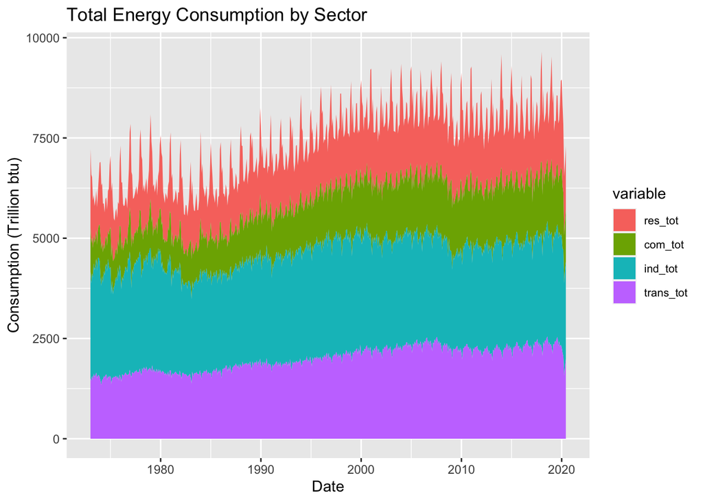

```r
# Setup the chart
ggplot(dt_tot, aes(x = month, y= value, fill = variable)) +
  geom_area(position = 'stack') + # Make a stacked area chart
  ggtitle("Total Energy Consumption by Sector") + # Title it
  ylab("Consumption (Trillion btu)") + # label axes
  xlab("Date") + # label axes
  theme(legend.text = element_text(size = 8)) +
  guides(fill = guide_legend(ncol = 1))
```

## Plot two types of charts

```r
# Groupby variable and year and sum over the months
# Create a variable year by running the function year over the variable I have called month
dt_prim[,year:=year(month)]
# Set the 'key' or 'index' of the dataframe as variable-year
setkey(dt_prim,variable,year)
dt_prim
```

| month | variable | value | year |
| --- | --- | --- | --- |
| 1973-01-01 | res_prim | 1339.270 | 1973 |
| 1973-02-01 | res_prim | 1174.899 | 1973 |
| 1973-03-01 | res_prim | 983.374 | 1973 |
| 1973-04-01 | res_prim | 715.391 | 1973 |
| 1973-05-01 | res_prim | 535.914 | 1973 |
| 1973-06-01 | res_prim | 366.934 | 1973 |
| 1973-07-01 | res_prim | 306.868 | 1973 |
| 1973-08-01 | res_prim | 313.317 | 1973 |
| 1973-09-01 | res_prim | 342.204 | 1973 |
| 1973-10-01 | res_prim | 448.425 | 1973 |

[output cut: 2840 more lines]

```r
# Now I can easily groupby the key and do operations on each group
yearly_primary <- dt_prim[,list(consumption_prim = sum(value)),key(dt_prim)]
yearly_primary
```

| variable | year | consumption_prim |
| --- | --- | --- |
| res_prim | 1973 | 8226.048 |
| res_prim | 1974 | 7908.597 |
| res_prim | 1975 | 7990.296 |
| res_prim | 1976 | 8391.829 |
| res_prim | 1977 | 8194.295 |
| res_prim | 1978 | 8260.601 |
| res_prim | 1979 | 7919.353 |
| res_prim | 1980 | 7439.201 |
| res_prim | 1981 | 7044.307 |
| res_prim | 1982 | 7147.052 |

[output cut: 230 more lines]

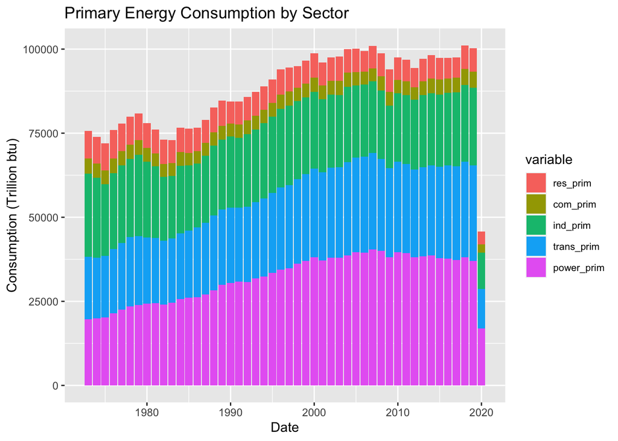

```r
# Setup the chart
ggplot(yearly_primary, aes(x = year, y= consumption_prim, fill = variable)) +
  geom_bar(position = 'stack', stat = 'identity') + # Make a stacked bar chart
  ggtitle("Primary Energy Consumption by Sector") + # Title it
  ylab("Consumption (Trillion btu)") + # label axes
  xlab("Date") + # label axes
  theme(legend.text = element_text(size = 8)) +
  guides(fill = guide_legend(ncol = 1))
```

## Joins

You need a unique key that matches both dataframes * Creating this key might take some work! * e.g state_company_id_plant_id by concatenating I’m going to stack the total energy data and join it to yearly_primary

```r
dt_tot[,year := year(month)]
setkey(dt_tot,variable,year)
yearly_tot <- dt_tot[,list(consumption_tot = sum(value)),key(dt_prim)]
yearly_tot <- dcast(yearly_tot, year ~ variable)
yearly_prim <- dcast(yearly_primary, year ~ variable)
# Yearly consumption by merging the two
merge(yearly_tot,yearly_prim)
```

| year | res_tot | com_tot | ind_tot | trans_tot | res_prim | com_prim | ind_prim | trans_prim | power_prim |
| --- | --- | --- | --- | --- | --- | --- | --- | --- | --- |
| 1973 | 14896.61 | 9544.904 | 32590.23 | 18612.84 | 8226.048 | 4422.983 | 24687.62 | 18577.29 | 19730.63 |
| 1974 | 14654.77 | 9395.285 | 31751.53 | 18120.49 | 7908.597 | 4259.260 | 23761.75 | 18087.24 | 19905.24 |
| 1975 | 14811.47 | 9494.435 | 29379.83 | 18245.05 | 7990.296 | 4059.355 | 21400.35 | 18210.55 | 20270.24 |
| 1976 | 15408.28 | 10064.471 | 31357.31 | 19100.84 | 8391.829 | 4371.646 | 22627.94 | 19066.74 | 21472.76 |
| 1977 | 15658.21 | 10209.552 | 32223.57 | 19821.66 | 8194.295 | 4258.327 | 23123.47 | 19786.28 | 22550.63 |
| 1978 | 16128.52 | 10512.439 | 32646.50 | 20617.13 | 8260.601 | 4309.113 | 23198.94 | 20582.83 | 23553.11 |
| 1979 | 15811.12 | 10649.417 | 33878.62 | 20471.57 | 7919.353 | 4365.967 | 24144.93 | 20437.28 | 23943.20 |
| 1980 | 15753.30 | 10581.560 | 31989.63 | 19695.05 | 7439.201 | 4105.417 | 22548.16 | 19657.46 | 24269.31 |
| 1981 | 15255.99 | 10618.493 | 30663.55 | 19512.69 | 7044.307 | 3837.341 | 21268.43 | 19476.46 | 24424.20 |
| 1982 | 15527.85 | 10862.914 | 27561.89 | 19089.87 | 7147.052 | 3864.647 | 18998.72 | 19052.82 | 23979.29 |

[output cut: 38 more lines]

## Energy Systems and Economics Primer for Cullen (2013)

- An emissions offset
- Dynamics and intermittency